# Data Exploration - Loan Data From Prosper

## Introduction

> This data set contains 113,937 loans with 81 variables on each loan, including loan amount, borrower/ interest rate, current loan status, borrower income and many others.

> The sole purpose of this project is to ascertain borrowers intent/ loan outcomes and communicate data findings using 10 - 15 of the variables. Find below, definition of our variables:

**ListingKey:** Unique key for each listing, same value as the 'key' used in the listing object in the API.

**ListingNumber:** The number that uniquely identifies the listing to the public as displayed on the website.

**ListingCreationDate:** The date the listing was created.

**CreditGrade:** The Credit rating that was assigned at the time the listing went live. Applicable for listings pre-2009 period and will only be populated for those listings.

**Term:** The length of the loan expressed in months.

**LoanStatus:** The current status of the loan: Cancelled, Chargedoff, Completed, Current, Defaulted, FinalPaymentInProgress, PastDue. The PastDue status will be accompanied by a delinquency bucket.

**ClosedDate:** Closed date is applicable for Cancelled, Completed, Chargedoff and Defaulted loan statuses.

**BorrowerAPR:** The Borrower's Annual Percentage Rate (APR) for the loan.

**BorrowerRate:** The Borrower's interest rate for this loan.

**LenderYield:** The Lender yield on the loan. Lender yield is equal to the interest rate on the loan less the servicing fee.

**EstimatedEffectiveYield:** Effective yield is equal to the borrower interest rate (i) minus the servicing fee rate, (ii) minus estimated uncollected interest on charge-offs, (iii) plus estimated collected late fees. Applicable for loans originated after July 2009.

**EstimatedLoss:** Estimated loss is the estimated principal loss on charge-offs. Applicable for loans originated after July 2009.

**EstimatedReturn:** The estimated return assigned to the listing at the time it was created. Estimated return is the difference between the Estimated Effective Yield and the Estimated Loss Rate. Applicable for loans originated after July 2009.

**ProsperRating (numeric):** The Prosper Rating assigned at the time the listing was created: 0 - N/A, 1 - HR, 2 - E, 3 - D, 4 - C, 5 - B, 6 - A, 7 - AA. Applicable for loans originated after July 2009.

**ProsperRating (Alpha):** The Prosper Rating assigned at the time the listing was created between AA - HR. Applicable for loans originated after July 2009.

**ProsperScore:** A custom risk score built using historical Prosper data. The score ranges from 1-10, with 10 being the best, or lowest risk score. Applicable for loans originated after July 2009.

**ListingCategory:** The category of the listing that the borrower selected when posting their listing: 0 - Not Available, 1 - Debt Consolidation, 2 - Home Improvement, 3 - Business, 4 - Personal Loan, 5 - Student Use, 6 - Auto, 7- Other, 8 - Baby&Adoption, 9 - Boat, 10 - Cosmetic Procedure, 11 - Engagement Ring, 12 - Green Loans, 13 - Household Expenses, 14 - Large Purchases, 15 - Medical/Dental, 16 - Motorcycle, 17 - RV, 18 - Taxes, 19 - Vacation, 20 - Wedding Loans

**BorrowerState:** The two letter abbreviation of the state of the address of the borrower at the time the Listing was created.

**Occupation:** The Occupation selected by the Borrower at the time they created the listing.

**EmploymentStatus:** The employment status of the borrower at the time they posted the listing.

**EmploymentStatusDuration:** The length in months of the employment status at the time the listing was created.

**IsBorrowerHomeowner:** A Borrower will be classified as a homowner if they have a mortgage on their credit profile or provide documentation confirming they are a homeowner.

**CurrentlyInGroup:** Specifies whether or not the Borrower was in a group at the time the listing was created.

**GroupKey:** The Key of the group in which the Borrower is a member of. Value will be null if the borrower does not have a group affiliation.

**DateCreditPulled:** The date the credit profile was pulled.

**CreditScoreRangeLower:** The lower value representing the range of the borrower's credit score as provided by a consumer credit rating agency.

**CreditScoreRangeUpper:** The upper value representing the range of the borrower's credit score as provided by a consumer credit rating agency.

**FirstRecordedCreditLine:** The date the first credit line was opened.

**CurrentCreditLines:** Number of current credit lines at the time the credit profile was pulled.

**OpenCreditLines:** Number of open credit lines at the time the credit profile was pulled.

**TotalCreditLinespast7years:** Number of credit lines in the past seven years at the time the credit profile was pulled.

**OpenRevolvingAccounts:** Number of open revolving accounts at the time the credit profile was pulled.

**OpenRevolvingMonthlyPayment:** Monthly payment on revolving accounts at the time the credit profile was pulled.

**InquiriesLast6Months:** Number of inquiries in the past six months at the time the credit profile was pulled.

**TotalInquiries:** Total number of inquiries at the time the credit profile was pulled.

**CurrentDelinquencies:** Number of accounts delinquent at the time the credit profile was pulled.

**AmountDelinquent:** Dollars delinquent at the time the credit profile was pulled.

**DelinquenciesLast7Years:** Number of delinquencies in the past 7 years at the time the credit profile was pulled.

**PublicRecordsLast10Years:** Number of public records in the past 10 years at the time the credit profile was pulled.

**PublicRecordsLast12Months:** Number of public records in the past 12 months at the time the credit profile was pulled.

**RevolvingCreditBalance:** Dollars of revolving credit at the time the credit profile was pulled.

**BankcardUtilization:** The percentage of available revolving credit that is utilized at the time the credit profile was pulled.

**AvailableBankcardCredit:** The total available credit via bank card at the time the credit profile was pulled.

**TotalTrades:** Number of trade lines ever opened at the time the credit profile was pulled.

**TradesNeverDelinquent:** Number of trades that have never been delinquent at the time the credit profile was pulled.

**TradesOpenedLast6Months:** Number of trades opened in the last 6 months at the time the credit profile was pulled.

**DebtToIncomeRatio:** The debt to income ratio of the borrower at the time the credit profile was pulled. This value is Null if the debt to income ratio is not available. This value is capped at 10.01 (any debt to income ratio larger than 1000% will be returned as 1001%).

**IncomeRange:** The income range of the borrower at the time the listing was created.

**IncomeVerifiable:** The borrower indicated they have the required documentation to support their income.

**StatedMonthlyIncome:** The monthly income the borrower stated at the time the listing was created.

**LoanKey:** Unique key for each loan. This is the same key that is used in the API.

**TotalProsperLoans:** Number of Prosper loans the borrower at the time they created this listing. This value will be null if the borrower had no prior loans.

**TotalProsperPaymentsBilled:** Number of on time payments the borrower made on Prosper loans at the time they created this listing. This value will be null if the borrower had no prior loans.

**OnTimeProsperPayments:** Number of on time payments the borrower had made on Prosper loans at the time they created this listing. This value will be null if the borrower has no prior loans.

**ProsperPaymentsLessThanOneMonthLate:** Number of payments the borrower made on Prosper loans that were less than one month late at the time they created this listing. This value will be null if the borrower had no prior loans.

**ProsperPaymentsOneMonthPlusLate:** Number of payments the borrower made on Prosper loans that were greater than one month late at the time they created this listing. This value will be null if the borrower had no prior loans.

**ProsperPrincipalBorrowed:** Total principal borrowed on Prosper loans at the time the listing was created. This value will be null if the borrower had no prior loans.

**ProsperPrincipalOutstanding:** Principal outstanding on Prosper loans at the time the listing was created. This value will be null if the borrower had no prior loans.

**ScorexChangeAtTimeOfListing:** Borrower's credit score change at the time the credit profile was pulled. This will be the change relative to the borrower's last Prosper loan. This value will be null if the borrower had no prior loans.

**LoanCurrentDaysDelinquent:** The number of days delinquent.

**LoanFirstDefaultedCycleNumber:** The cycle the loan was charged off. If the loan has not charged off the value will be null.

**LoanMonthsSinceOrigination:** Number of months since the loan originated.

**LoanNumber:** Unique numeric value associated with the loan.

**LoanOriginalAmount:** The origination amount of the loan.

**LoanOriginationDate:** The date the loan was originated.

**LoanOriginationQuarter:** The quarter in which the loan was originated.

**MemberKey:** The unique key that is associated with the borrower. This is the same identifier that is used in the API member object.

**MonthlyLoanPayment:** The scheduled monthly loan payment.

**LP_CustomerPayments:** Pre charge-off cumulative gross payments made by the borrower on the loan. If the loan has charged off, this value will exclude any recoveries.

**LP_CustomerPrincipalPayments:** Pre charge-off cumulative principal payments made by the borrower on the loan. If the loan has charged off, this value will exclude any recoveries.

**LP_InterestandFees:** Pre charge-off cumulative interest and fees paid by the borrower. If the loan has charged off, this value will exclude any recoveries.

**LP_ServiceFees:** Cumulative service fees paid by the investors who have invested in the loan.

**LP_CollectionFees:** Cumulative collection fees paid by the investors who have invested in the loan.

**LP_GrossPrincipalLoss:** The gross charged off amount of the loan.

**LP_NetPrincipalLoss:** The principal that remains uncollected after any recoveries.

**LP_NonPrincipalRecoverypayments:** The interest and fee component of any recovery payments. The current payment policy applies payments in the following order: Fees, interest, principal.

**PercentFunded:** Percent the listing was funded.

**Recommendations:** Number of recommendations the borrower had at the time the listing was created.

**InvestmentFromFriendsCount:** Number of friends that made an investment in the loan.

**InvestmentFromFriendsAmount:** Dollar amount of investments that were made by friends.

**Investors:** The number of investors that funded the loan.

## Preliminary Wrangling

```python
# importing all packages and setting plots to be embedded inline
import numpy as np
import pandas as pd
import matplotlib.pyplot as plt
import seaborn as sb

%matplotlib inline
```

```python
sb.set_palette("dark")
sb.set(rc={'axes.facecolor':'lightgrey', 'figure.facecolor':'whitesmoke'})
```

> Loading in my dataset. Would afterwards describe its properties through the questions that follow it. Setting a basis for my future exploration goals.

```python
prosper = pd.read_csv('prosperLoanData.csv')
prosper.head()
```

|  | ListingKey | ListingNumber | ListingCreationDate | CreditGrade | Term | LoanStatus | ClosedDate | BorrowerAPR | BorrowerRate | LenderYield | ... | LP_ServiceFees | LP_CollectionFees | LP_GrossPrincipalLoss | LP_NetPrincipalLoss | LP_NonPrincipalRecoverypayments | PercentFunded | Recommendations | InvestmentFromFriendsCount | InvestmentFromFriendsAmount | Investors |
| --- | --- | --- | --- | --- | --- | --- | --- | --- | --- | --- | --- | --- | --- | --- | --- | --- | --- | --- | --- | --- | --- |
| 0 | 1021339766868145413AB3B | 193129 | 2007-08-26 19:09:29.263000000 | C | 36 | Completed | 2009-08-14 00:00:00 | 0.16516 | 0.1580 | 0.1380 | ... | -133.18 | 0.0 | 0.0 | 0.0 | 0.0 | 1.0 | 0 | 0 | 0.0 | 258 |
| 1 | 10273602499503308B223C1 | 1209647 | 2014-02-27 08:28:07.900000000 | NaN | 36 | Current | NaN | 0.12016 | 0.0920 | 0.0820 | ... | 0.00 | 0.0 | 0.0 | 0.0 | 0.0 | 1.0 | 0 | 0 | 0.0 | 1 |
| 2 | 0EE9337825851032864889A | 81716 | 2007-01-05 15:00:47.090000000 | HR | 36 | Completed | 2009-12-17 00:00:00 | 0.28269 | 0.2750 | 0.2400 | ... | -24.20 | 0.0 | 0.0 | 0.0 | 0.0 | 1.0 | 0 | 0 | 0.0 | 41 |
| 3 | 0EF5356002482715299901A | 658116 | 2012-10-22 11:02:35.010000000 | NaN | 36 | Current | NaN | 0.12528 | 0.0974 | 0.0874 | ... | -108.01 | 0.0 | 0.0 | 0.0 | 0.0 | 1.0 | 0 | 0 | 0.0 | 158 |
| 4 | 0F023589499656230C5E3E2 | 909464 | 2013-09-14 18:38:39.097000000 | NaN | 36 | Current | NaN | 0.24614 | 0.2085 | 0.1985 | ... | -60.27 | 0.0 | 0.0 | 0.0 | 0.0 | 1.0 | 0 | 0 | 0.0 | 20 |

5 rows × 81 columns

### What is the structure of your dataset?

```python
prosper.info()
```

```
<class 'pandas.core.frame.DataFrame'>
RangeIndex: 113937 entries, 0 to 113936
Data columns (total 81 columns):
 #   Column                               Non-Null Count   Dtype
---  ------                               --------------   -----
 0   ListingKey                           113937 non-null  object
 1   ListingNumber                        113937 non-null  int64
 2   ListingCreationDate                  113937 non-null  object
 3   CreditGrade                          28953 non-null   object
 4   Term                                 113937 non-null  int64
 5   LoanStatus                           113937 non-null  object
 6   ClosedDate                           55089 non-null   object
 7   BorrowerAPR                          113912 non-null  float64
 8   BorrowerRate                         113937 non-null  float64
 9   LenderYield                          113937 non-null  float64
```

[output cut: 73 more lines]

> Initial **data structure** is 113937 rows by 81 columns. But, going by the irregular non-null column count, something seems amiss. Lets find out.

```python
#Some basic stats

prosper.describe(include='all')
```

|  | ListingKey | ListingNumber | ListingCreationDate | CreditGrade | Term | LoanStatus | ClosedDate | BorrowerAPR | BorrowerRate | LenderYield | ... | LP_ServiceFees | LP_CollectionFees | LP_GrossPrincipalLoss | LP_NetPrincipalLoss | LP_NonPrincipalRecoverypayments | PercentFunded | Recommendations | InvestmentFromFriendsCount | InvestmentFromFriendsAmount | Investors |
| --- | --- | --- | --- | --- | --- | --- | --- | --- | --- | --- | --- | --- | --- | --- | --- | --- | --- | --- | --- | --- | --- |
| count | 113937 | 1.139370e+05 | 113937 | 28953 | 113937.000000 | 113937 | 55089 | 113912.000000 | 113937.000000 | 113937.000000 | ... | 113937.000000 | 113937.000000 | 113937.000000 | 113937.000000 | 113937.000000 | 113937.000000 | 113937.000000 | 113937.000000 | 113937.000000 | 113937.000000 |
| unique | 113066 | NaN | 113064 | 8 | NaN | 12 | 2802 | NaN | NaN | NaN | ... | NaN | NaN | NaN | NaN | NaN | NaN | NaN | NaN | NaN | NaN |
| top | 17A93590655669644DB4C06 | NaN | 2013-10-02 17:20:16.550000000 | C | NaN | Current | 2014-03-04 00:00:00 | NaN | NaN | NaN | ... | NaN | NaN | NaN | NaN | NaN | NaN | NaN | NaN | NaN | NaN |
| freq | 6 | NaN | 6 | 5649 | NaN | 56576 | 105 | NaN | NaN | NaN | ... | NaN | NaN | NaN | NaN | NaN | NaN | NaN | NaN | NaN | NaN |
| mean | NaN | 6.278857e+05 | NaN | NaN | 40.830248 | NaN | NaN | 0.218828 | 0.192764 | 0.182701 | ... | -54.725641 | -14.242698 | 700.446342 | 681.420499 | 25.142686 | 0.998584 | 0.048027 | 0.023460 | 16.550751 | 80.475228 |
| std | NaN | 3.280762e+05 | NaN | NaN | 10.436212 | NaN | NaN | 0.080364 | 0.074818 | 0.074516 | ... | 60.675425 | 109.232758 | 2388.513831 | 2357.167068 | 275.657937 | 0.017919 | 0.332353 | 0.232412 | 294.545422 | 103.239020 |
| min | NaN | 4.000000e+00 | NaN | NaN | 12.000000 | NaN | NaN | 0.006530 | 0.000000 | -0.010000 | ... | -664.870000 | -9274.750000 | -94.200000 | -954.550000 | 0.000000 | 0.700000 | 0.000000 | 0.000000 | 0.000000 | 1.000000 |
| 25% | NaN | 4.009190e+05 | NaN | NaN | 36.000000 | NaN | NaN | 0.156290 | 0.134000 | 0.124200 | ... | -73.180000 | 0.000000 | 0.000000 | 0.000000 | 0.000000 | 1.000000 | 0.000000 | 0.000000 | 0.000000 | 2.000000 |
| 50% | NaN | 6.005540e+05 | NaN | NaN | 36.000000 | NaN | NaN | 0.209760 | 0.184000 | 0.173000 | ... | -34.440000 | 0.000000 | 0.000000 | 0.000000 | 0.000000 | 1.000000 | 0.000000 | 0.000000 | 0.000000 | 44.000000 |
| 75% | NaN | 8.926340e+05 | NaN | NaN | 36.000000 | NaN | NaN | 0.283810 | 0.250000 | 0.240000 | ... | -13.920000 | 0.000000 | 0.000000 | 0.000000 | 0.000000 | 1.000000 | 0.000000 | 0.000000 | 0.000000 | 115.000000 |
| max | NaN | 1.255725e+06 | NaN | NaN | 60.000000 | NaN | NaN | 0.512290 | 0.497500 | 0.492500 | ... | 32.060000 | 0.000000 | 25000.000000 | 25000.000000 | 21117.900000 | 1.012500 | 39.000000 | 33.000000 | 25000.000000 | 1189.000000 |

11 rows × 81 columns

Going by the above stats, our 81 columns must have alot of missing values plus data type issues. But before cleaning, I need to make a decision on what interests me in the dataframe. This would greatly reduce workload.

### What is/are the main feature(s) of interest in your dataset?

```python
#Should first get a general feel of the dataframe

prosper.sample(10)
```

|  | ListingKey | ListingNumber | ListingCreationDate | CreditGrade | Term | LoanStatus | ClosedDate | BorrowerAPR | BorrowerRate | LenderYield | ... | LP_ServiceFees | LP_CollectionFees | LP_GrossPrincipalLoss | LP_NetPrincipalLoss | LP_NonPrincipalRecoverypayments | PercentFunded | Recommendations | InvestmentFromFriendsCount | InvestmentFromFriendsAmount | Investors |
| --- | --- | --- | --- | --- | --- | --- | --- | --- | --- | --- | --- | --- | --- | --- | --- | --- | --- | --- | --- | --- | --- |
| 104488 | D8D23483664510419F853F4 | 458614 | 2010-05-16 17:14:35.677000000 | NaN | 36 | Completed | 2013-02-22 00:00:00 | 0.39153 | 0.3500 | 0.3400 | ... | -17.82 | 0.0 | 0.00 | 0.00 | 0.0 | 1.0 | 0 | 0 | 0.0 | 17 |
| 17335 | 4613356391133893645B82E | 671619 | 2012-11-15 22:29:31.987000000 | NaN | 36 | Chargedoff | 2013-06-01 00:00:00 | 0.35797 | 0.3177 | 0.3077 | ... | -1.42 | 0.0 | 3940.21 | 3940.21 | 0.0 | 1.0 | 0 | 0 | 0.0 | 32 |
| 86364 | EEFA3422206132112A87E25 | 347993 | 2008-06-10 11:18:35.707000000 | D | 36 | Chargedoff | 2010-01-24 00:00:00 | 0.16461 | 0.1430 | 0.1330 | ... | -17.82 | 0.0 | 1189.84 | 1189.84 | 0.0 | 1.0 | 0 | 0 | 0.0 | 37 |
| 83613 | 64FD336528597906866FA65 | 8250 | 2006-04-25 21:45:17.403000000 | A | 36 | Completed | 2006-09-11 00:00:00 | 0.09588 | 0.0890 | 0.0840 | ... | -3.95 | 0.0 | 0.00 | 0.00 | 0.0 | 1.0 | 0 | 0 | 0.0 | 66 |
| 80327 | EBDE35220904842579663F7 | 517549 | 2011-07-22 12:00:22.727000000 | NaN | 36 | Completed | 2013-04-26 00:00:00 | 0.35643 | 0.3199 | 0.3099 | ... | -56.17 | 0.0 | 0.00 | 0.00 | 0.0 | 1.0 | 0 | 0 | 0.0 | 1 |
| 99660 | F2DF3583623906672166848 | 839595 | 2013-07-15 12:20:00.043000000 | NaN | 36 | Current | NaN | 0.19645 | 0.1599 | 0.1499 | ... | -137.45 | 0.0 | 0.00 | 0.00 | 0.0 | 1.0 | 0 | 0 | 0.0 | 1 |
| 42194 | 687F35871150940198A3B1B | 882627 | 2013-08-28 15:24:32.813000000 | NaN | 36 | Current | NaN | 0.32538 | 0.2859 | 0.2759 | ... | -16.68 | 0.0 | 0.00 | 0.00 | 0.0 | 1.0 | 0 | 0 | 0.0 | 1 |
| 50129 | A53D35823041440639ECC70 | 817804 | 2013-06-21 13:51:33.857000000 | NaN | 60 | Current | NaN | 0.25359 | 0.2284 | 0.2184 | ... | -161.13 | 0.0 | 0.00 | 0.00 | 0.0 | 1.0 | 0 | 0 | 0.0 | 1 |
| 21734 | 047F357396561294682B5A2 | 735077 | 2013-03-23 08:55:46.457000000 | NaN | 60 | Current | NaN | 0.33040 | 0.3032 | 0.2932 | ... | -25.53 | 0.0 | 0.00 | 0.00 | 0.0 | 1.0 | 0 | 0 | 0.0 | 4 |
| 42587 | C038337223137762623EC54 | 58911 | 2006-11-08 12:38:45.680000000 | D | 36 | Completed | 2009-01-29 00:00:00 | 0.20735 | 0.2000 | 0.1950 | ... | -20.05 | 0.0 | 0.00 | 0.00 | 0.0 | 1.0 | 0 | 0 | 0.0 | 20 |

10 rows × 81 columns

> The main feature(s) of interest in my dataset:
> - Features that aided in predictions of whether or not a person would default on his/her loan.
> - Features that aided in assigning ProsperRatings.

Now, we can quickly choose columns of interest and do the much needed cleaning afterwards.

### What features in the dataset do you think will help support your investigation into your feature(s) of interest?

```python
#Quickly making a list of "columns of interests" and passing them to "main_columns"

main_columns = ['Term', 'LoanStatus', 'ProsperRating (Alpha)', 'ListingCategory (numeric)', 'EmploymentStatus',
    'DelinquenciesLast7Years', 'StatedMonthlyIncome', 'TotalProsperLoans', 'LoanOriginalAmount',
    'LoanOriginationDate']
```

```python
#Assigning "main_columns" to a new dataframe, "prosper_main"

prosper_main = prosper[main_columns]
prosper_main.sample(20)
```

|  | Term | LoanStatus | ProsperRating (Alpha) | ListingCategory (numeric) | EmploymentStatus | DelinquenciesLast7Years | StatedMonthlyIncome | TotalProsperLoans | LoanOriginalAmount | LoanOriginationDate |
| --- | --- | --- | --- | --- | --- | --- | --- | --- | --- | --- |
| 62891 | 36 | Current | C | 1 | Employed | 0.0 | 14333.333333 | NaN | 25000 | 2013-12-06 00:00:00 |
| 40474 | 36 | Current | C | 14 | Other | 1.0 | 5083.333333 | NaN | 2500 | 2013-06-19 00:00:00 |
| 93763 | 36 | Completed | B | 1 | Employed | 1.0 | 6666.666667 | NaN | 15000 | 2013-09-26 00:00:00 |
| 10532 | 36 | Chargedoff | NaN | 0 | Full-time | 0.0 | 3000.000000 | NaN | 2500 | 2007-11-14 00:00:00 |
| 110497 | 36 | Current | A | 1 | Employed | 0.0 | 2583.333333 | NaN | 10000 | 2014-03-10 00:00:00 |
| 68579 | 36 | Defaulted | NaN | 0 | Not available | 21.0 | 6083.333333 | NaN | 5000 | 2006-10-13 00:00:00 |
| 80429 | 60 | Current | C | 1 | Employed | 0.0 | 7266.666667 | NaN | 18000 | 2013-12-10 00:00:00 |
| 104261 | 60 | Current | C | 1 | Employed | 0.0 | 4250.000000 | NaN | 15000 | 2013-06-07 00:00:00 |
| 43764 | 36 | Completed | A | 1 | Full-time | 0.0 | 3000.000000 | NaN | 8000 | 2010-06-16 00:00:00 |
| 59518 | 36 | Completed | D | 7 | Employed | 0.0 | 3500.000000 | NaN | 2000 | 2011-01-20 00:00:00 |
| 64734 | 60 | Current | B | 1 | Full-time | 29.0 | 3500.000000 | NaN | 5000 | 2012-02-07 00:00:00 |
| 58419 | 36 | Completed | C | 1 | Employed | 0.0 | 6666.666667 | NaN | 20000 | 2013-09-24 00:00:00 |
| 96597 | 36 | Current | HR | 1 | Employed | 0.0 | 4583.333333 | NaN | 2858 | 2012-12-19 00:00:00 |
| 7331 | 60 | Current | B | 19 | Employed | 0.0 | 11333.333333 | NaN | 4200 | 2013-07-18 00:00:00 |
| 40890 | 36 | Completed | NaN | 0 | Full-time | 0.0 | 2500.000000 | NaN | 4500 | 2007-04-12 00:00:00 |
| 5822 | 60 | Completed | C | 19 | Employed | 0.0 | 10333.333333 | NaN | 10000 | 2013-01-08 00:00:00 |
| 33126 | 36 | Current | A | 1 | Employed | 0.0 | 3333.333333 | NaN | 10000 | 2013-10-16 00:00:00 |
| 27238 | 36 | Chargedoff | HR | 1 | Employed | 0.0 | 5000.000000 | NaN | 4000 | 2011-12-27 00:00:00 |
| 75336 | 36 | Completed | AA | 1 | Employed | 0.0 | 11666.666667 | NaN | 14000 | 2012-10-10 00:00:00 |
| 17663 | 60 | Current | B | 1 | Self-employed | 0.0 | 3333.333333 | NaN | 10000 | 2013-11-20 00:00:00 |

Great! Now, the next thing one notices is the missing values under the **ProsperRating (Alpha)** and **TotalprosperLoans**

```python
#But first, lets get an idea of how much missing values there are and what else we might find...

prosper_main.info()
```

```
<class 'pandas.core.frame.DataFrame'>
RangeIndex: 113937 entries, 0 to 113936
Data columns (total 10 columns):
 #   Column                     Non-Null Count   Dtype
---  ------                     --------------   -----
 0   Term                       113937 non-null  int64
 1   LoanStatus                 113937 non-null  object
 2   ProsperRating (Alpha)      84853 non-null   object
 3   ListingCategory (numeric)  113937 non-null  int64
 4   EmploymentStatus           111682 non-null  object
 5   DelinquenciesLast7Years    112947 non-null  float64
 6   StatedMonthlyIncome        113937 non-null  float64
 7   TotalProsperLoans          22085 non-null   float64
 8   LoanOriginalAmount         113937 non-null  int64
 9   LoanOriginationDate        113937 non-null  object
dtypes: float64(3), int64(3), object(4)
memory usage: 8.7+ MB
```

Okay... **LoanOriginationDate** ought to be in *date-time* data type and **StatedMonthlyIncome** ought to be *int*... lets get down to cleaning all issues sighted...

```python
#First... dropping missing values under "ProsperRating (Alpha)" using "dropna" and at same time, resetting the index so
#everything is in order...

prosper_main = prosper_main.dropna(subset=['ProsperRating (Alpha)']).reset_index()
```

```python
#Done?

prosper_main.info()
```

```
<class 'pandas.core.frame.DataFrame'>
RangeIndex: 84853 entries, 0 to 84852
Data columns (total 11 columns):
 #   Column                     Non-Null Count  Dtype
---  ------                     --------------  -----
 0   index                      84853 non-null  int64
 1   Term                       84853 non-null  int64
 2   LoanStatus                 84853 non-null  object
 3   ProsperRating (Alpha)      84853 non-null  object
 4   ListingCategory (numeric)  84853 non-null  int64
 5   EmploymentStatus           84853 non-null  object
 6   DelinquenciesLast7Years    84853 non-null  float64
 7   StatedMonthlyIncome        84853 non-null  float64
 8   TotalProsperLoans          19797 non-null  float64
 9   LoanOriginalAmount         84853 non-null  int64
 10  LoanOriginationDate        84853 non-null  object
dtypes: float64(3), int64(4), object(4)
memory usage: 7.1+ MB
```

Great! We've got uniform "non-null count" in all except **TotalProsperLoans**... lets fix that.

```python
#We'll fill all nans and missing values in "Total_ProsperLoans" with zero (0) to bring it up to uniformity... since it is much
#needed in our analysis.

prosper_main['TotalProsperLoans'] = prosper_main['TotalProsperLoans'].fillna(0)
prosper_main['TotalProsperLoans'].info()
```

```
<class 'pandas.core.series.Series'>
RangeIndex: 84853 entries, 0 to 84852
Series name: TotalProsperLoans
Non-Null Count  Dtype
--------------  -----
84853 non-null  float64
dtypes: float64(1)
memory usage: 663.0 KB
```

84853 entries, just like other columns... beautiful... next, we fix all data type issues.

```python
#Converting "LoanOriginationDate" from 'object' to 'date-time' and "StatedMonthlyIncome" from 'str' to 'int'

prosper_main['LoanOriginationDate'] = pd.to_datetime(prosper_main['LoanOriginationDate'])
prosper_main['StatedMonthlyIncome'] = pd.to_numeric(prosper_main['StatedMonthlyIncome'], errors='coerce').fillna(0).astype('int64').round(0)


prosper_main['LoanOriginationDate'].info()
prosper_main['StatedMonthlyIncome'].info()
```

```
<class 'pandas.core.series.Series'>
RangeIndex: 84853 entries, 0 to 84852
Series name: LoanOriginationDate
Non-Null Count  Dtype
--------------  -----
84853 non-null  datetime64[ns]
dtypes: datetime64[ns](1)
memory usage: 663.0 KB
<class 'pandas.core.series.Series'>
RangeIndex: 84853 entries, 0 to 84852
Series name: StatedMonthlyIncome
Non-Null Count  Dtype
--------------  -----
84853 non-null  int64
dtypes: int64(1)
memory usage: 663.0 KB
```

```python
#A last look at "prosper_main"...

prosper_main.info()
```

```
<class 'pandas.core.frame.DataFrame'>
RangeIndex: 84853 entries, 0 to 84852
Data columns (total 11 columns):
 #   Column                     Non-Null Count  Dtype
---  ------                     --------------  -----
 0   index                      84853 non-null  int64
 1   Term                       84853 non-null  int64
 2   LoanStatus                 84853 non-null  object
 3   ProsperRating (Alpha)      84853 non-null  object
 4   ListingCategory (numeric)  84853 non-null  int64
 5   EmploymentStatus           84853 non-null  object
 6   DelinquenciesLast7Years    84853 non-null  float64
 7   StatedMonthlyIncome        84853 non-null  int64
 8   TotalProsperLoans          84853 non-null  float64
 9   LoanOriginalAmount         84853 non-null  int64
 10  LoanOriginationDate        84853 non-null  datetime64[ns]
dtypes: datetime64[ns](1), float64(2), int64(5), object(3)
memory usage: 7.1+ MB
```

> Now, to answer the question... **"What features in the dataset do you think will help support your investigation into your feature(s) of interest?"**
> - First, I expect that **ProsperRating (Alpha)** would lend the most support to determining a borrowers chances of defaulting.
> - Secondly, **LoanOriginalAmount** would also affect chances of defaulting.
> - **StatedMonthlyIncome**, **EmploymentStatus** and **DelinquenciesLast7Years** would lend the most support to assigning **ProsperRating (Alpha)**.

## Univariate Exploration

> Here, I explore, analyze and visualize each one column I think would be important to my findings... to do this, I've decided to take my needed columns in the order they appear on the dataframe...

### LoanStatus

> - How many current loans were there?
> - How many loans were defaulted?
> - How many were completed?

```python
#First...we see what the column values look like...

prosper_main['LoanStatus'].value_counts()
```

```
Current                   56576
Completed                 19664
Chargedoff                 5336
Defaulted                  1005
Past Due (1-15 days)        806
Past Due (31-60 days)       363
Past Due (61-90 days)       313
Past Due (91-120 days)      304
Past Due (16-30 days)       265
FinalPaymentInProgress      205
Past Due (>120 days)         16
Name: LoanStatus, dtype: int64
```

Okay... that's alot of stuff that aren't where they're supposed to be...

```python
#I'll have to replace: the whole of "chargedoff" with "Defaulted", all "Past Due" within 30 days with "Current", all "Past Due"
#beyond 30 days with "Defaulted" and "FinalPaymentInProgress" with "Current".

prosper_main['LoanStatus'] = prosper_main['LoanStatus'].replace(
    ['Chargedoff', 'Past Due (1-15 days)', 'Past Due (31-60 days)', 'Past Due (61-90 days)',
     'Past Due (91-120 days)', 'Past Due (16-30 days)', 'FinalPaymentInProgress', 'Past Due (>120 days)'],
    ['Defaulted', 'Current', 'Defaulted', 'Defaulted', 'Defaulted', 'Current', 'Current', 'Defaulted']
)
prosper_main['LoanStatus'].value_counts() #Taking value counts again to confirm changes...
```

```
Current      57852
Completed    19664
Defaulted     7337
Name: LoanStatus, dtype: int64
```

Rationale for the changes:

> - Current Loan means an Eligible Loan as to which any Monthly Payment is less than 30 days past due as of any date of determination. (Source: https://www.lawinsider.com/dictionary/current-loan#)
> - A charge-off means the lender or creditor has written the account off as a loss, and the account is closed to future charges. (Source: https://www.equifax.com/personal/education/credit/report/charge-offs-faq/#)

Now, lets go visualize!

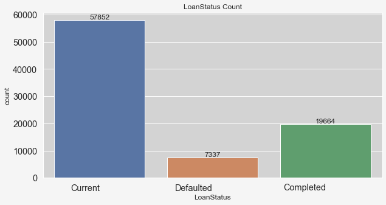

```python
# Would use a count plot
plt.figure(figsize = [10, 5]) #Setting size of the plot

ls = sb.countplot(data = prosper_main, x = 'LoanStatus'); #seaborn countplot passed off to function "ls"

plt.xticks(rotation=0, horizontalalignment='right', fontweight='light', fontsize='large') #xticks parameters entered

plt.yticks(rotation=0, horizontalalignment='right', fontweight='light', fontsize='large') #what I want my y-axis to look like?

ls.bar_label(ls.containers[0]) #labels on each of the bars so I know exactly what count each represent

ls.set_title('LoanStatus Count'); #title of plot
```

#### First Thought

> - **Current** - 57852 loans. This here is the hugest chunk of the borrowings.
> - **Defaulted** - 7337 loans. This is relatively small when compared with other two loan categories.
> - **Completed** - 19664 loans.

### ProsperRating (Alpha)

> - What was the most common **ProsperRating (Alpha)** and how many borrowers got it?
> - What was the least prevalent **ProsperRating (Alpha)** and the number of borrowers that got it?

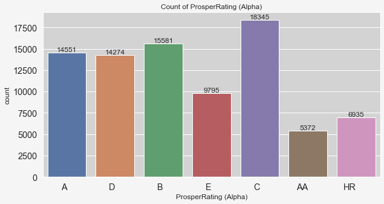

```python
# Another count plot
plt.figure(figsize = [10, 5]) #Size of my plot

pr = sb.countplot(data = prosper_main, x = 'ProsperRating (Alpha)'); #seaborn countplot passed to func. 'pr'
plt.xticks(rotation=0, horizontalalignment='right', fontweight='light', fontsize='large') #look of the gradings on x axis?

plt.yticks(rotation=0, horizontalalignment='right', fontweight='light', fontsize='large') #look of the gradings on y-axis

pr.bar_label(pr.containers[0]) #labelling each bar with a count so I know exactly what each represents...

pr.set_title('Count of ProsperRating (Alpha)'); #title of my plot..
```

#### Second Thought

> - **C** was the most common **ProsperRating (Alpha)**. 18345 borrowers got assigned the rating.
> - **AA** was the least prevalent **ProsperRating (Alpha)** and 5372 were assigned the rating.

### ListingCategory (numeric)

> - What were the most prevalent and the least prevalent **ListingCategory** of borrowers respectively?

```python
#Lets see what the column looks like...
prosper_main['ListingCategory (numeric)'].value_counts()
```

```
1     53180
7      9218
2      6801
3      5298
6      2237
13     1996
15     1522
18      885
14      876
20      771
19      768
16      304
5       274
11      217
8       199
10       91
9        85
12       59
17       52
0        20
Name: ListingCategory (numeric), dtype: int64
```

OKAY... going by our data dictionary, Number "4" is visibly missing from the column... but that's not even a problem... issue is, there's a lot of unique integers for what is supposed to be a future categorical data column...

```python
#Would have to convert to categorical data by using the actual names of the values instead of integers, then, I'll trim down on
#number of unique entries using the data dictionary referenced in my introduction above... I begin by using ".map" to create a
#list housing the unique entries I want, representing "0" and everything else from "7" with "Other"

lc_list = prosper_main['ListingCategory (numeric)'].map({0:'Other', 1:'Debt Consolidation', 2:'Home Improvement', 3:'Business', 5:'Student Use',
                                                                       6:'Auto', 7:'Other', 8:'Other', 9:'Other', 10:'Other',
                                                                     11:'Other', 12:'Other', 13:'Other', 14:'Other',  15:'Other',
                                                                       16:'Other', 17:'Other', 18:'Other', 19:'Other', 20:'Other'})
prosper_main['ListingCategory (numeric)'] = lc_list #I pass the list into my column...
```

```python
#It worked?
prosper_main['ListingCategory (numeric)'].value_counts()
```

```
Debt Consolidation    53180
Other                 17063
Home Improvement       6801
Business               5298
Auto                   2237
Student Use             274
Name: ListingCategory (numeric), dtype: int64
```

Super! We go visualize now..

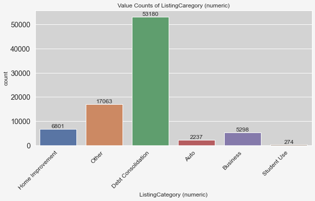

```python
# Would use a count plot
plt.figure(figsize = [10, 5])

lc = sb.countplot(data = prosper_main, x = 'ListingCategory (numeric)');
plt.xticks(rotation=45, horizontalalignment='right', fontweight='light', fontsize='medium')
plt.yticks(rotation=0, horizontalalignment='right', fontweight='light', fontsize='large')
lc.bar_label(lc.containers[0])
lc.set_title('Value Counts of ListingCaregory (numeric)');
```

#### Third Thought

> - At a count of 53180, **Debt Consolidation** was the most prevalent **Listing Category** and **Student Use**(count: 274) was the least prevalent.

### EmploymentStatus

> - How many borrowers were employed?
> - How many borrowers were unemployed?
> - How many borrowers were self employed?
> - Were there more borrowers working **Part-time** than those regularly **Employed**

```python
#First...lets see what we have...

prosper_main['EmploymentStatus'].value_counts()
```

```
Employed         67310
Full-time         7927
Self-employed     4538
Other             3806
Not employed       649
Retired            367
Part-time          256
Name: EmploymentStatus, dtype: int64
```

Okay... "**Full-time**" basically means "**Employed**" and "**Other**" can come under "**Part-time**" since all remaining categories are clearly defined... would have to fix that...

```python
#We use a replace function...

prosper_main['EmploymentStatus'] = prosper_main['EmploymentStatus'].replace(['Full-time', 'Other'],['Employed', 'Part-time'])

prosper_main['EmploymentStatus'].value_counts()
```

```
Employed         75237
Self-employed     4538
Part-time         4062
Not employed       649
Retired            367
Name: EmploymentStatus, dtype: int64
```

75237 **Employed**, 4538 **Self-employed**, 649 **Not-employed**, 367 **Retired** and 4062 **Part-time** employed borrowers... transformation done! Lets go visualize...

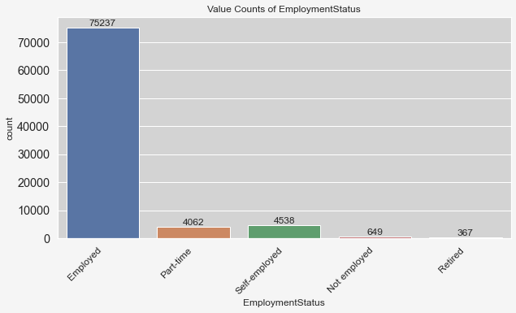

```python
#Another count plot would do for visualization...
plt.figure(figsize=(10,5))

Emp = sb.countplot(data=prosper_main, x='EmploymentStatus');
Emp.set(xlabel='EmploymentStatus')
Emp.bar_label(Emp.containers[0])
plt.xticks(rotation=45, horizontalalignment='right', fontweight='light', fontsize='medium')
plt.yticks(rotation=0, horizontalalignment='right', fontweight='light', fontsize='large')
Emp.set_title('Value Counts of EmploymentStatus');
plt.show()
```

### DelinquenciesLast7Years

> - How many borrowers had zero delinquencies in the last 7 years?

```python
#First, 20 samples of rows in the column data...

prosper_main['DelinquenciesLast7Years'].sample(20)
```

```
2170      0.0
82429     2.0
16932     0.0
73214     0.0
39621     0.0
6656      0.0
15940     0.0
26143    32.0
17924     0.0
75316     0.0
1968     20.0
18270    25.0
68864    11.0
46870     0.0
31286     0.0
2259      0.0
64346     0.0
20311     0.0
7247     34.0
30825     0.0
Name: DelinquenciesLast7Years, dtype: float64
```

Apparently, this is discrete data with few issues: **the decimals... excessive amount of values and initial data type... lets fix that...**

```python
#First... we temporarily convert to int type data...to get rid of the '.0' in each entry by replace and setting regex to true

prosper_main['DelinquenciesLast7Years'] = prosper_main['DelinquenciesLast7Years'].astype(int).replace('\.0', '', regex=True)
```

```python
#Value counts to confirm changes...
prosper_main['DelinquenciesLast7Years'].value_counts()
```

```
0     59990
1      2787
3      2234
2      2000
4      1754
      ...
84        2
98        1
96        1
93        1
97        1
Name: DelinquenciesLast7Years, Length: 99, dtype: int64
```

Up next... we define a function to trim down the entries and change to categorical data...

```python
#First... a list... more like a map of what each integer ought to convert to... I chose "Zero" to "Seven", with "8" representing
#"Over Seven." I then defined a function (convert) that changes every number "0 to 7" in my main column to their "word outputs"
#in my map, while at same time returning "Over Seven" for every "8" and every number not found in my map.

dl_list = {0:'Zero', 1:'One', 2:'Two', 3:'Three', 4:'Four', 5:'Five', 6:'Six', 7:'Seven', 8:'Over Seven'}
def convert(row):
    delinquency = row['DelinquenciesLast7Years']
    if  delinquency in dl_list:
        return dl_list[delinquency]
    else:
        return dl_list[8]

prosper_main['DelinquenciesLast7Years'] = prosper_main.apply(convert, axis=1) #I applied my newly defined function (convert)
```

```python
#Dit it work?

prosper_main['DelinquenciesLast7Years'].value_counts()
```

```
Zero          59990
Over Seven    12498
One            2787
Three          2234
Two            2000
Four           1754
Five           1258
Six            1219
Seven          1113
Name: DelinquenciesLast7Years, dtype: int64
```

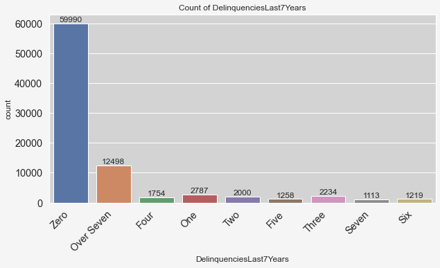

```python
# Another count plot
plt.figure(figsize = [10, 5]) #Size of my plot

dls = sb.countplot(data = prosper_main, x = 'DelinquenciesLast7Years'); #seaborn countplot passed to func. 'dls'
plt.xticks(rotation=45, horizontalalignment='right', fontweight='light', fontsize='large') #look of the gradings on x axis?

plt.yticks(rotation=0, horizontalalignment='right', fontweight='light', fontsize='large') #look of the gradings on y-axis

dls.bar_label(dls.containers[0]) #labelling each bar with a count so I know exactly what each represents...

dls.set_title('Count of DelinquenciesLast7Years'); #title of my plot..
```

#### Fifth Thought

> - 59990 borrowers committed zero delinquencies in the last 7 years.

### StatedMonthlyIncome

> - Atleast how many borrowers earned up to the average StatedMonthlyIncome?

```python
#First... average StatedMonthlyIncome...

average_smi = prosper_main['StatedMonthlyIncome'].mean()
```

```python
#Next... I iterate through the dataframe, through StatedMonthlyIncome column, sorting entries by all monthly earnings equal or
#greater than average then...passing it all to a new dataframe (inc_mean_above)

inc_mean_above = prosper_main[prosper_main['StatedMonthlyIncome'] >= average_smi]
```

```python
limit = len(prosper_main[prosper_main['StatedMonthlyIncome'] >= average_smi]) #Finding the number of objects in my dataframe and
                                                                                #passing it to new function, "limit"
```

Lets visualize!

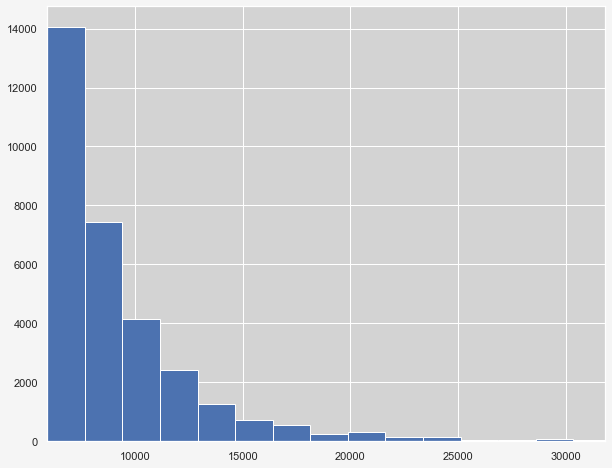

```python
plt.figure(figsize = [10, 8]) #Size of figure...

smi_abv_avg = plt.hist(data=inc_mean_above, x='StatedMonthlyIncome', histtype='barstacked', bins=(1000)); #calling the histogram
                                                                                                        #plot func.. passing it
                                                                                                        #smi_abv_avg

plt.xlim(average_smi, limit); #x-axis limit set as ranging from average_smi to the "limit" function from earlier...
```

#### Sixth Thought

> - At least, 14000 borrrowers earned up to the average StatedMonthlyIncome (5931).

### LoanOriginalAmount

> - How many times was the highest original loan amount taken?

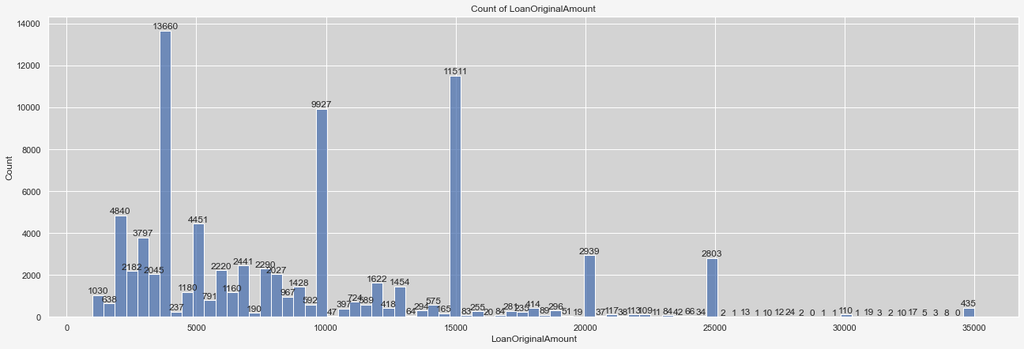

```python
plt.figure(figsize=(22,7))

Amt = sb.histplot(data=prosper_main, x="LoanOriginalAmount");
Amt.set(xlabel='LoanOriginalAmount')
Amt.bar_label(Amt.containers[0])
## Amt.bar_label(Amt.containers[0][Amt.containers[0]!=0])
Amt.set_title('Count of LoanOriginalAmount'); #title of my plot..
plt.show()
```

### Discuss the distribution(s) of your variable(s) of interest. Were there any unusual points? Did you need to perform any transformations?

> The hugest chunk of the borrowings were current loans, coming tops at 57852 loans. Defaulted loans at 7337 borrowings was relatively small when compared with the other two loan categories. This means, more people (19664) completed than defaulted in paying their loans.

> The number one stated reason people took loans was "DebtConsolidation" and the least stated reason was "Student Use." Apparently, more borrowers needed new loans to pay off existing ones than they needed it to improve their homes, finance businesses, get new cars, finance education etc.

> The largest group of borrowers by virtue of employment status were the "Employed". and the least populous group were the "Not-employed" and "Retired".

> Most of the borrowers (59990) had no records of delinquencies in the last 7 years, 2787 committed just one delinquency in 7 years and 12498 had record of over seven delinquencies in 7 years.

> Atleast, 14000 borrowers earned up to the average stated monthly income (5931) and between 7000 and 8000 borrowers earned almost 10000 monthly. Meanwhile, less than 2000 borrowers earned above 30000 per month.

> Of course, I had to perform transformations with: LoanStatus, ListingCategory (numeric), EmploymentStatus and DelinquenciesLast7Years.

### Of the features you investigated, were there any unusual distributions? Did you perform any operations on the data to tidy, adjust, or change the form of the data? If so, why did you do this?

> There were so many outliers in the average StatedMonthlyIncome distribution, it also had very large range and was excessively right skewed. I didn't clean or adjust the data, all I did was zoom in on the plotted visualization by using my average mean income and count of monthly income greater or equal to average as my limits respectively. This quicly revealed that, atleast 14000 borrowers earned up to the average stated monthly income (5931).

## Bivariate Exploration

> In this section, I investigate relationships between pairs of variables in my data. It is worth noting that variables I cover here have been introduced in some fashion in the previous section (univariate exploration).

### LoanStatus and ProsperRating (Alpha)

> - What was the most common ProsperRating amongst loan defaulters?
> - What was the most prevalent ProsperRating amongst borrowers that completed their loan payments?
> - What was the most prevalent ProsperRating amongst borrowers with current loans?
> - Going by LoanStatus, which category of borrowers had the best ProsperRating (Alpha)?

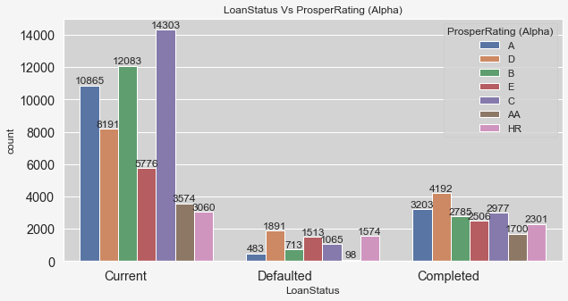

```python
plt.figure(figsize = [10, 5]) #Size of my plot

prd = sb.countplot(data = prosper_main, x = 'LoanStatus', hue = 'ProsperRating (Alpha)');#seaborn countplot passed to func.'prd'

plt.xticks(rotation=0, horizontalalignment='right', fontweight='light', fontsize='large') #look of the gradings on x axis?

plt.yticks(rotation=0, horizontalalignment='right', fontweight='light', fontsize='large') #look of the gradings on y-axis

prd.bar_label(prd.containers[0]) #labelling each bar with a count so I know exactly what each represents...
prd.bar_label(prd.containers[1])
prd.bar_label(prd.containers[2])
prd.bar_label(prd.containers[3])
prd.bar_label(prd.containers[4])
prd.bar_label(prd.containers[5])
prd.bar_label(prd.containers[6])
prd.set_title('LoanStatus Vs ProsperRating (Alpha)'); #title of my plot..
```

Up next... we find the category, by LoanStatus, that had the best ProsperRating (Alpha)...

```python
#Theoretically, comparing ratios of the counts of highest to lowest ProsperRating in each LoanStatus category should get us
#there...so... we compare count ratios of ratings AA to HR for every category...

pr_ratio_current = 3574/3060
pr_ratio_current
```

```
1.1679738562091504
```

```python
pr_ratio_defaulted = 98/1574
pr_ratio_defaulted
```

```
0.062261753494282084
```

```python
pr_ratio_completed = 1700/2301
pr_ratio_completed
```

```
0.7388092133854846
```

```python
#Now, we build a dictionary for our count ratios... and pass it into a new dataframe, prosper_loan_ratios...

loan_pr_ratios = {'ProsperRatingRatio': [1.17, 0.06, 0.74], 'LoanStatus': ['Current', 'Defaulted', 'Completed']}
prosper_loan_ratios = pd.DataFrame(loan_pr_ratios)
```

Up next... we visualize...

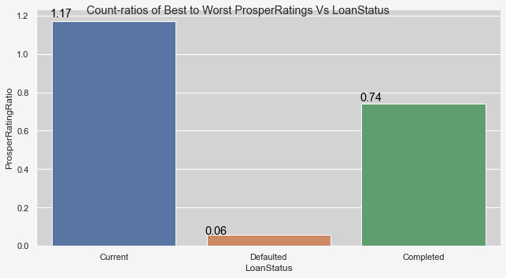

```python
lsp_r = sb.catplot(data = prosper_loan_ratios, x = 'LoanStatus', y = 'ProsperRatingRatio', kind = 'bar', legend=True);#seaborn countplot passed to func.'lsp_r'
lsp_r.fig.set_size_inches(10,5)
lsp_r.fig.suptitle('Count-ratios of Best to Worst ProsperRatings Vs LoanStatus')
ax = lsp_r.facet_axis(0,0)
for p in ax.patches:
    ax.text(p.get_x() - 0.01,
            p.get_height() * 1.02,
            format(p.get_height()),
            color='black',
            rotation='horizontal',
            size='large')
```

#### First Thought

> **D** was the most common **ProsperRating** amongst Defaulters.

> The most prevalent **ProsperRating** amongst those that completed payments was also **D**.

> The most prevalent **ProsperRating** amongst current loan borrowers was **C**.

> Current loan borrowers had the best ProsperRating of all... going by best to worst count ratios.

### LoanStatus and ListingCategory (numeric)

> - What was the most common ListingCategory amongst loan defaulters?
> - What was the most common ListingCategory amongst borrowers that completed their loan payments?

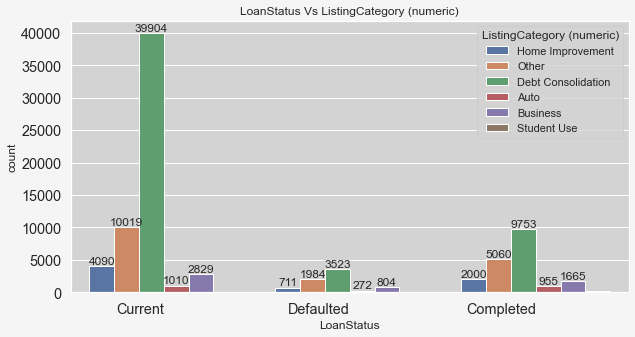

```python
plt.figure(figsize = [10, 5]) #Size of my plot

lsl = sb.countplot(data = prosper_main, x = 'LoanStatus', hue = 'ListingCategory (numeric)');
plt.xticks(rotation=0, horizontalalignment='right', fontweight='light', fontsize='large') #look of the gradings on x axis?

plt.yticks(rotation=0, horizontalalignment='right', fontweight='light', fontsize='large') #look of the gradings on y-axis

lsl.bar_label(lsl.containers[0]) #labelling each bar with a count so I know exactly what each represents...
lsl.bar_label(lsl.containers[1])
lsl.bar_label(lsl.containers[2])
lsl.bar_label(lsl.containers[3])
lsl.bar_label(lsl.containers[4])
lsl.set_title('LoanStatus Vs ListingCategory (numeric)'); #title of my plot..
```

#### Second Thought

> - The most common listing category amongst loan defaulters was **Debt Consolidation**
> - The highest prevaling listing category amongst those that made complete payment was also **Debt Consolidation**

### LoanStatus and EmploymentStatus

> - What was the employment status of borrowers with the highest defaults.
> - What was the employment status of borrowers the highest number of complete payments?

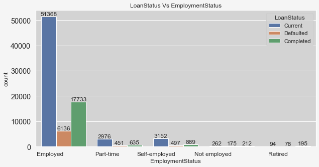

```python
plt.figure(figsize = [10, 5])
lse = sb.countplot(data = prosper_main, x = 'EmploymentStatus', hue = 'LoanStatus');
plt.xticks(rotation=0, horizontalalignment='right', fontweight='light', fontsize='medium') #look of the gradings on x axis?

plt.yticks(rotation=0, horizontalalignment='right', fontweight='light', fontsize='large') #look of the gradings on y-axis

lse.bar_label(lse.containers[0]) #labelling each bar with a count so I know exactly what each represents...
lse.bar_label(lse.containers[1])
lse.bar_label(lse.containers[2])

lse.set_title('LoanStatus Vs EmploymentStatus'); #title of my plot..
```

#### Third Thought

> - The most prevalent employment status of borrowers that defaulted weas **Employed**.
> - The most common employment status of borrowers that completed payments was also **Employed**.

### LoanStatus and DelinquenciesLast7Years

> Going by ratios of "Zero" to "Over Seven" deliquency counts, which group of borrowers, by LoanStatus, were most likely to record "Zero" deliquency counts?

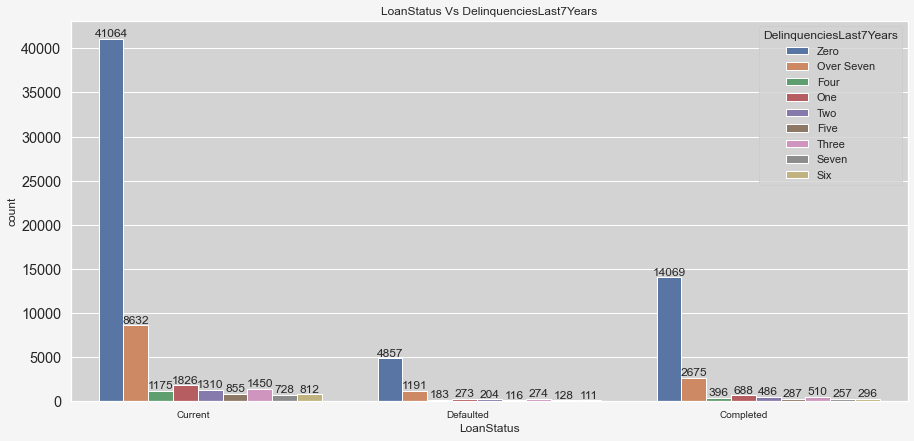

```python
#First... we plot... coz... why not?

plt.figure(figsize = [15, 7])
lsdel = sb.countplot(data = prosper_main, x = 'LoanStatus', hue = 'DelinquenciesLast7Years');
plt.xticks(rotation=0, horizontalalignment='right', fontweight='light', fontsize='small') #look of the gradings on x axis?

plt.yticks(rotation=0, horizontalalignment='right', fontweight='light', fontsize='large') #look of the gradings on y-axis

lsdel.bar_label(lsdel.containers[0]) #labelling each bar with a count so I know exactly what each represents...
lsdel.bar_label(lsdel.containers[1])
lsdel.bar_label(lsdel.containers[2])
lsdel.bar_label(lsdel.containers[3])
lsdel.bar_label(lsdel.containers[4])
lsdel.bar_label(lsdel.containers[5])
lsdel.bar_label(lsdel.containers[6])
lsdel.bar_label(lsdel.containers[7])
lsdel.bar_label(lsdel.containers[8])

lsdel.set_title('LoanStatus Vs DelinquenciesLast7Years'); #title of my plot..
```

Okay... next stop... ratios of the needed counts...

```python
delq__ratio_current = 41064/8632
delq__ratio_current
```

```
4.757182576459685
```

```python
delq__ratio_defaulted = 4857/1191
delq__ratio_defaulted
```

```
4.07808564231738
```

```python
delq__ratio_completed = 14069/2675
delq__ratio_completed
```

```
5.259439252336448
```

```python
#Now, we build a dictionary for our count ratios... and pass it into a new dataframe, delq_loan_ratios...

delq_lstatus_ratios = {'DelinquenciesRatio': [4.76, 4.08, 5.26], 'LoanStatus': ['Current', 'Defaulted', 'Completed']}
delq_loan_ratios = pd.DataFrame(delq_lstatus_ratios)
```

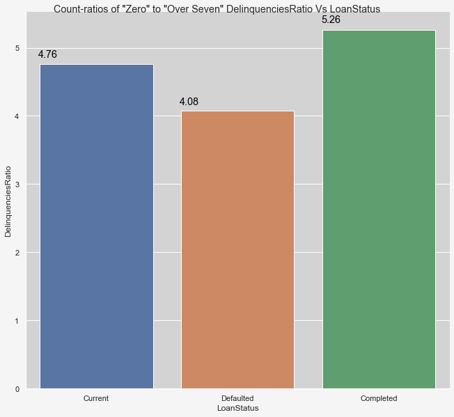

```python
dlql_r = sb.catplot(data = delq_loan_ratios, x = 'LoanStatus', y = 'DelinquenciesRatio', kind = 'bar', legend=True);#seaborn countplot passed to func.'dlql_r'
dlql_r.fig.set_size_inches(10,9)
dlql_r.fig.suptitle('Count-ratios of "Zero" to "Over Seven" DelinquenciesRatio Vs LoanStatus')
ax = dlql_r.facet_axis(0,0)
for p in ax.patches:
    ax.text(p.get_x() - 0.01,
            p.get_height() * 1.02,
            format(p.get_height()),
            color='black',
            rotation='horizontal',
            size='large')
```

#### Fourth Thought

> - Borrowers that made complete payments were most likely to record zero delinquencies compared to others.

### LoanStatus and StatedMonthlyIncome

```python
#recall?
average_smi
```

```
5930.852768906226
```

```python
#Now, we locate all StatedMonthlyIncome greater than mean of monthly incomes and pass it off to a new dataframe...
#..."income_more_than_mean"
income_more_than_mean = (prosper_main[prosper_main['StatedMonthlyIncome'] > average_smi])
```

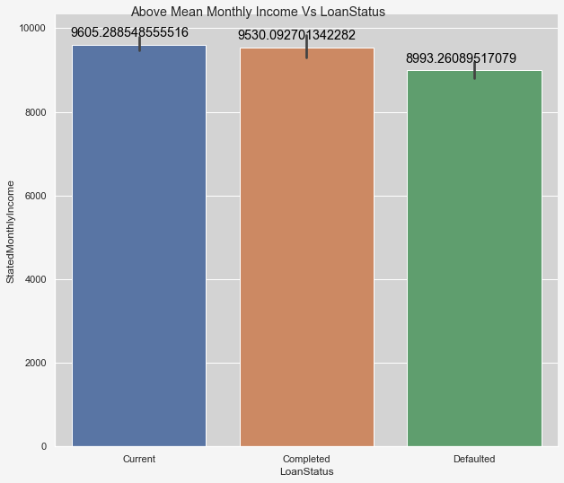

```python
#Lets visualize!

abv_mls = sb.catplot(x='LoanStatus', y='StatedMonthlyIncome', data=income_more_than_mean, kind='bar', legend=True)
abv_mls.fig.set_size_inches(10,8)

abv_mls.fig.suptitle('Above Mean Monthly Income Vs LoanStatus')


ax = abv_mls.facet_axis(0,0)
for p in ax.patches:
    ax.text(p.get_x() - 0.01,
            p.get_height() * 1.02,
            format(p.get_height()),
            color='black',
            rotation='horizontal',
            size='large')
```

```python
#We move on to the other side... find all monthly incomes below average earnings and pass to new dataframe, "income_below_mean"
income_below_mean = (prosper_main[prosper_main['StatedMonthlyIncome'] < average_smi])
```

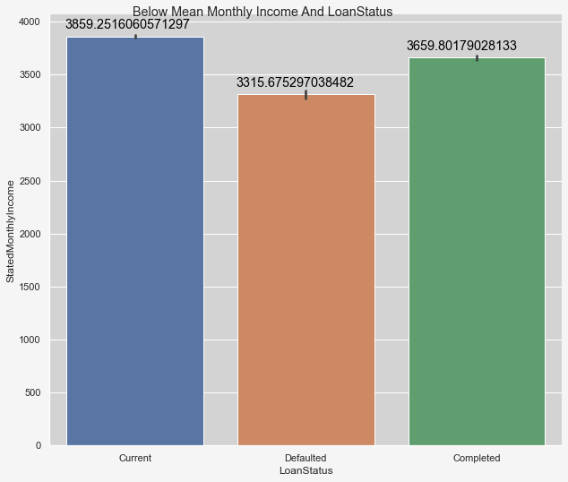

```python
#Lets visualize!

blw_mls = sb.catplot(x='LoanStatus', y='StatedMonthlyIncome', data=income_below_mean, kind='bar', legend=True)
blw_mls.fig.set_size_inches(10,8)

blw_mls.fig.suptitle('Below Mean Monthly Income And LoanStatus')

ax = blw_mls.facet_axis(0,0)
for p in ax.patches:
    ax.text(p.get_x() - 0.01,
            p.get_height() * 1.02,
            format(p.get_height()),
            color='black',
            rotation='horizontal',
            size='large')
```

### LoanStatus and LoanOriginalAmount

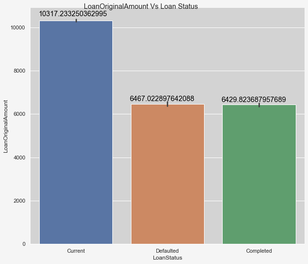

```python
#Straight to visuals...

dl = sb.catplot(x='LoanStatus', y='LoanOriginalAmount', data=prosper_main, kind='bar', legend=True)
dl.fig.set_size_inches(10,8)

dl.fig.suptitle('LoanOriginalAmount Vs Loan Status')

ax = dl.facet_axis(0,0)
for p in ax.patches:
    ax.text(p.get_x() - 0.01,
            p.get_height() * 1.02,
            format(p.get_height()),
            color='black',
            rotation='horizontal',
            size='large')
```

### ProsperRating (Alpha) and EmploymentStatus

> - What was the most assigned **ProsperRating** amongst the self employed and how many borrowers got it?
> - What was the most assigned **ProsperRating** overall under **Employed** and how many borrowers got it?
> - What was the least assigned prosper rating amongst the **Employed**? How many borrowers got it.

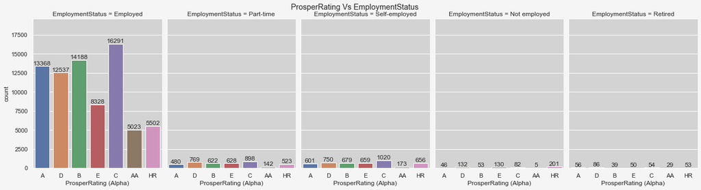

```python
pr_e = sb.catplot(x='ProsperRating (Alpha)', data=prosper_main, kind='count', col='EmploymentStatus')
pr_e.fig.set_size_inches(18, 5)
pr_e.fig.subplots_adjust(top=0.9)

pr_e.fig.suptitle('ProsperRating Vs EmploymentStatus')

for ax in pr_e.axes.ravel():

    for c in ax.containers:
        labels = [(v.get_height()) for v in c]
        ax.bar_label(c, labels=labels, label_type='edge')
    ax.margins(y=0.2)

plt.show()
```

### ProsperRating (Alpha) and DelinquenciesLast7Years

> Going by ratios, which ProsperRating (Alpha) would likely record the most "Zero" delinquencies?

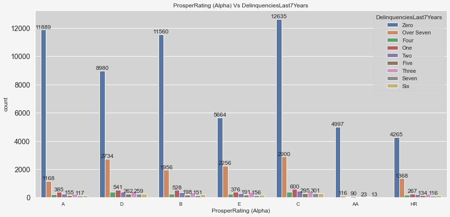

```python
#First... we plot... coz... why not?

plt.figure(figsize = [15, 7])
pr_delq = sb.countplot(data = prosper_main, x = 'ProsperRating (Alpha)', hue = 'DelinquenciesLast7Years');
plt.xticks(rotation=0, horizontalalignment='right', fontweight='light', fontsize='small') #look of the gradings on x axis?

plt.yticks(rotation=0, horizontalalignment='right', fontweight='light', fontsize='large') #look of the gradings on y-axis

pr_delq.bar_label(pr_delq.containers[0]) #labelling each bar with a count so I know exactly what each represents...
pr_delq.bar_label(pr_delq.containers[1])

pr_delq.bar_label(pr_delq.containers[3])

pr_delq.bar_label(pr_delq.containers[5])

pr_delq.bar_label(pr_delq.containers[7])


pr_delq.set_title('ProsperRating (Alpha) Vs DelinquenciesLast7Years'); #title of my plot..
```

Up next... ratios...

```python
dlq_ratio_hr = 4265/1368
dlq_ratio_hr
```

```
3.117690058479532
```

```python
dlq_ratio_e = 5664/2256
dlq_ratio_e
```

```
2.5106382978723403
```

```python
dlq_ratio_d = 8980/2734
dlq_ratio_d
```

```
3.284564740307242
```

```python
dlq_ratio_c = 12635/2900
dlq_ratio_c
```

```
4.356896551724138
```

```python
dlq_ratio_b = 11560/1956
dlq_ratio_b
```

```
5.91002044989775
```

```python
dlq_ratio_a = 11889/1168
dlq_ratio_a
```

```
10.178938356164384
```

```python
dlq_ratio_aa = 4997/116
dlq_ratio_aa
```

```
43.077586206896555
```

```python
#Now, we build a dictionary for our count ratios... and pass it into a new dataframe, delq_prosper_ratios...

delq_pr_ratios = {'DelinquenciesRatio': [3.12, 2.51, 3.29, 4.36, 5.91, 10.18, 43.08], 'ProsperRating (Alpha)': ['HR', 'E', 'D', 'C', 'B', 'A', 'AA']}
delq_prosper_ratios = pd.DataFrame(delq_pr_ratios)
```

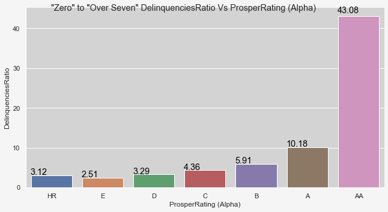

```python
#Straight to visuals...

dlq_pr = sb.catplot(x='ProsperRating (Alpha)', y='DelinquenciesRatio', data=delq_prosper_ratios, kind='bar', legend=True)
dlq_pr.fig.set_size_inches(10,5)

dlq_pr.fig.suptitle('"Zero" to "Over Seven" DelinquenciesRatio Vs ProsperRating (Alpha)')

ax = dlq_pr.facet_axis(0,0)
for p in ax.patches:
    ax.text(p.get_x() - 0.01,
            p.get_height() * 1.02,
            format(p.get_height()),
            color='black',
            rotation='horizontal',
            size='large')
```

#### Eight Thought

> - Borrowers with ProsperRating AA are the likeliest to record Zero delinquencies.

### DelinquenciesLast7Years and EmploymentStatus

> Which employment status recorded the most Zero delinquencies?

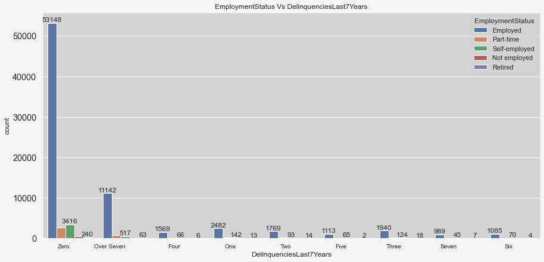

```python
plt.figure(figsize = [15, 7])
delq_emp = sb.countplot(data = prosper_main, x = 'DelinquenciesLast7Years', hue = 'EmploymentStatus');
plt.xticks(rotation=0, horizontalalignment='right', fontweight='light', fontsize='small') #look of the gradings on x axis?

plt.yticks(rotation=0, horizontalalignment='right', fontweight='light', fontsize='large') #look of the gradings on y-axis

delq_emp.bar_label(delq_emp.containers[0]) #labelling each bar with a count so I know exactly what each represents...

delq_emp.bar_label(delq_emp.containers[2])

delq_emp.bar_label(delq_emp.containers[4])


delq_emp.set_title('EmploymentStatus Vs DelinquenciesLast7Years'); #title of my plot..
```

#### Thought Nine

> - **Employed** borrowers recorded the most Zero delinquencies.

## Multivariate Exploration

> Over here, I create plots of three or more variables to investigate my data even further. I justify my investigations, and follow from my work in the previous sections.

### LoanStatus, StatedMonthlyIncome and EmploymentStatus

> - What is the relationship between **LoanStatus**, **StatedMonthlyIncome** and **EmploymentStatus**?

For this, we compare Loan Status, Stated Monthly Income and Employment Status of borrowers that earned above average monthly income.

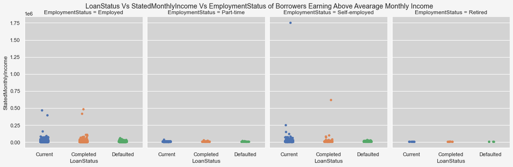

```python
loan_inc_emp = sb.catplot(x='LoanStatus', y='StatedMonthlyIncome', data=income_more_than_mean, kind='strip', col='EmploymentStatus', col_wrap=4, legend=True)
loan_inc_emp.fig.set_size_inches(15, 5)
loan_inc_emp.fig.subplots_adjust(top=0.9)

loan_inc_emp.fig.suptitle('LoanStatus Vs StatedMonthlyIncome Vs EmploymentStatus of Borrowers Earning Above Avearage Monthly Income')



plt.show()
```

### LoanStatus, LoanOrginalAmount and ListingCategory (numeric)

> - What is the relationship between **LoanStatus**, **LoanOriginalAmount** and **ListingCategory (numeric)**?

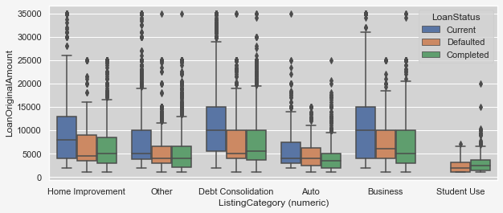

```python
plt.figure(figsize = [10, 4]);
loan_amt_listing = sb.boxplot(data=prosper_main, x='ListingCategory (numeric)', y= 'LoanOriginalAmount', hue='LoanStatus');
```

### DelinquenciesLast7Years, EmploymentStatus and LoanStatus

> - Going by delinquencies and Employment status, which group of borrowers haad the most share of current loans?

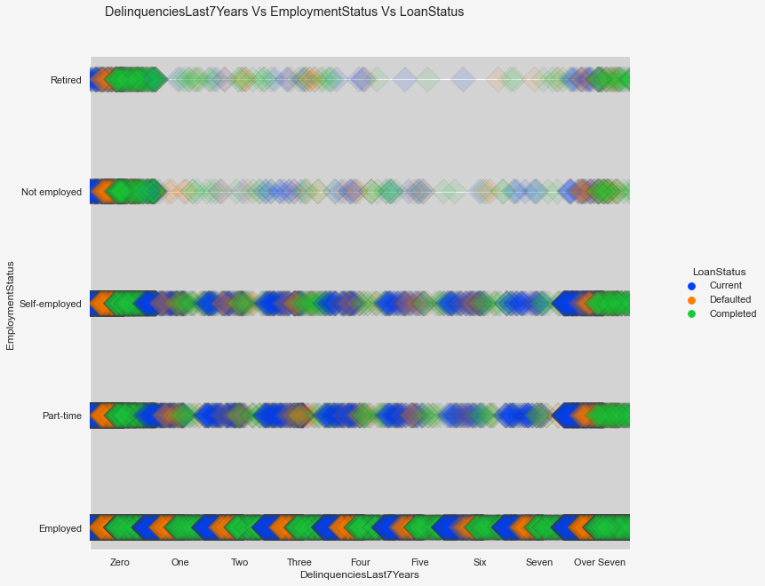

```python
dl_em_ln = sb.catplot(y='EmploymentStatus', x='DelinquenciesLast7Years', data=prosper_main, kind = 'strip',
                      palette = 'bright', hue = 'LoanStatus', jitter = 1.000000000000001,
                      order = ['Zero', 'One', 'Two', 'Three', 'Four', 'Five', 'Six',
                               'Seven', 'Over Seven'], s=20, marker="D", linewidth=1,
                      alpha=.1, dodge =True, legend=True
                     )
dl_em_ln.fig.set_size_inches(15,10)
dl_em_ln.fig.subplots_adjust(top=0.9,right=0.86)
dl_em_ln.fig.suptitle('DelinquenciesLast7Years Vs EmploymentStatus Vs LoanStatus');
```

#### Third Thought

> - Going by the density of blue colors in my strip plot above, Employed, self employed and Part time workers, regardless of number of delinquencies, had the most shares of the current loans.

##### Bonus Thoughts...

> *Employed borrowers naturally got more loans despite having the highest number of loan delinquencies "Over Seven". See the density of "green" at the lower right corner of my strip plot as reference*.

> *Compared to other groups, employed borrowers got loans regardless of their delinquencies history...*

### LoanStatus, ProsperRating (Alpha) and EmploymentStatus

> - Of all employed borrowers, what was the ProsperRating with the highest **Completed to Defaulted ratio**?

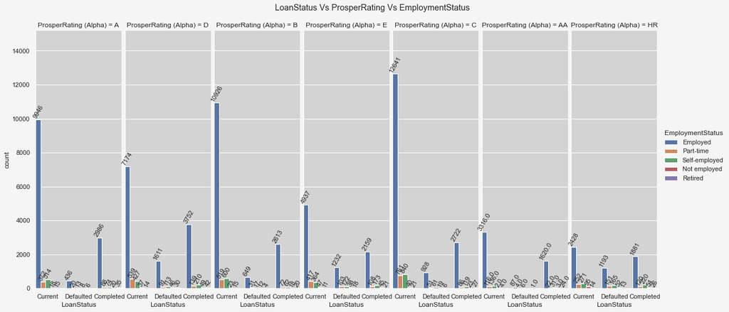

```python
#First, lets see a visual of counts for Employed borrowers with Completed and Defaulted loans based on their ProsperRatings...

loan_prosper_emp = sb.catplot(x='LoanStatus', data=prosper_main, kind='count', col='ProsperRating (Alpha)', hue='EmploymentStatus', col_wrap=7, legend=True)
loan_prosper_emp.fig.set_size_inches(17,8)
loan_prosper_emp.fig.subplots_adjust(top=0.9, right=0.9)

loan_prosper_emp.fig.suptitle('LoanStatus Vs ProsperRating Vs EmploymentStatus')

for ax in loan_prosper_emp.axes.ravel():

    for c in ax.containers:
        labels = [(v.get_height()) for v in c]
        ax.bar_label(c, labels=labels, label_type='edge', rotation=60, size=11)
    ax.margins(y=0.2)
    ax.margins(x=0)
plt.show()
```

Now, we find **Completed to Defaulted ratios** of **Employed** borrowers for each **ProsperRating (Alpha)**...

```python
emp_prosp_ratio_AA = 1620/87
emp_prosp_ratio_AA
```

```
18.620689655172413
```

```python
emp_prosp_ratio_A = 2986/436
emp_prosp_ratio_A
```

```
6.848623853211009
```

```python
emp_prosp_ratio_B = 2613/649
emp_prosp_ratio_B
```

```
4.026194144838213
```

```python
emp_prosp_ratio_C = 2722/928
emp_prosp_ratio_C
```

```
2.9331896551724137
```

```python
emp_prosp_ratio_D = 3752/1611
emp_prosp_ratio_D
```

```
2.3289882060831784
```

```python
emp_prosp_ratio_E = 2159/1232
emp_prosp_ratio_E
```

```
1.7524350649350648
```

```python
emp_prosp_ratio_HR = 1881/1193
emp_prosp_ratio_HR
```

```
1.5766974015088013
```

```python
#We create a quick data dictionary (emp_prosp_ratio) from above ratios and pass it into a new dataframe, prosp_ratio..
emp_prosp_ratio  = {'ratios': [18.62, 6.85, 4.03, 2.93, 2.33, 1.75, 1.58], 'prosper_rating': ['AA', 'A', 'B', 'C', 'D', 'E', 'HR']}
prosp_ratio = pd.DataFrame(emp_prosp_ratio)
```

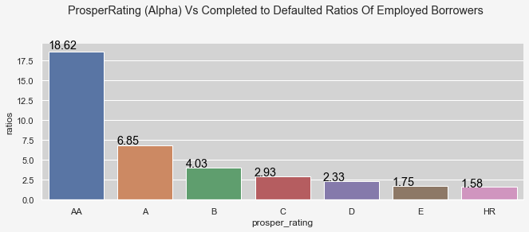

```python
#Straight to visuals...

ratio_prosp = sb.catplot(x='prosper_rating', y='ratios', data=prosp_ratio, kind='bar', legend=True)
ratio_prosp.fig.set_size_inches(12,4)
ratio_prosp.fig.subplots_adjust(top=0.81,right=0.86)
ratio_prosp.fig.suptitle('ProsperRating (Alpha) Vs Completed to Defaulted Ratios Of Employed Borrowers')

ax = ratio_prosp.facet_axis(0,0)
for p in ax.patches:
    ax.text(p.get_x() - 0.01,
            p.get_height() * 1.02,
            format(p.get_height()),
            color='black',
            rotation='horizontal',
            size='large')
```

#### Fourth Thought

> - Of all employed borrowers, **AA** was the **ProsperRating (Alpha)** with the highest **Completed to Defaulted ratio**.

### Other Relationships That Might Exist

```python
prosper_main.corr()
```

|  | index | Term | StatedMonthlyIncome | TotalProsperLoans | LoanOriginalAmount |
| --- | --- | --- | --- | --- | --- |
| index | 1.000000 | -0.004632 | 0.000109 | 0.002746 | -0.002719 |
| Term | -0.004632 | 1.000000 | 0.009257 | 0.002209 | 0.339117 |
| StatedMonthlyIncome | 0.000109 | 0.009257 | 1.000000 | 0.003552 | 0.182869 |
| TotalProsperLoans | 0.002746 | 0.002209 | 0.003552 | 1.000000 | -0.078841 |
| LoanOriginalAmount | -0.002719 | 0.339117 | 0.182869 | -0.078841 | 1.000000 |

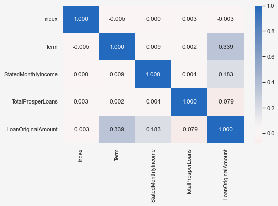

```python
plt.figure(figsize=[8, 5])
sb.heatmap(prosper_main.corr(), annot = True, fmt = '.3f', cmap = 'vlag_r', center = 0);
```

#### Fifth Thought

> - There is some fair positive correlation between loan term and original loan amount, very minimal positive correlation between original loan amount and monthly income and a most negligible negative correlation between loan amount and total prosper loans.

### Talk about some of the relationships you observed in this part of the investigation. Were there features that strengthened each other in terms of looking at your feature(s) of interest?

Employed and Self employed borrowers earning above the average monthly income complete more loans payment than all other groups under employment status. Employment status and Loan status strengthened ProsperRating (Alpha). Again, employment Status and monthly income are great pointers to whether or not a borrower would default or complete payment.